# sumary

[figure not shown]

Giới thiệu Phân tích Dữ liệu F1 Mùa Giải 2024

Chào mừng đến với dự án phân tích chuyên sâu về dữ liệu Formula 1 mùa giải 2024! F1 không chỉ là cuộc đua tốc độ mà còn là sân chơi của chiến lược, công nghệ và dữ liệu khổng lồ. Mùa giải 2024 đã mang đến nhiều diễn biến bất ngờ, những màn trình diễn đỉnh cao và những cuộc cạnh tranh gay cấn. Bằng cách khai thác và phân tích dữ liệu từ mọi chặng đua, chúng ta có thể vén màn những yếu tố ẩn đằng sau thành công hay thất bại của các đội và cá nhân tay đua.

Dự án này sẽ đi sâu vào các số liệu thống kê chi tiết từ mọi khía cạnh của mùa giải – từ hiệu suất xe, chiến thuật pit stop, lựa chọn lốp, cho đến ảnh hưởng của điều kiện thời tiết và đặc điểm từng đường đua. Mục tiêu không chỉ là trình bày lại các con số, mà là biến chúng thành những hiểu biết có giá trị, giúp người hâm mộ, chuyên gia và những ai quan tâm đến F1 có cái nhìn sâu sắc hơn về môn thể thao tốc độ này.

Mục tiêu Phân tích Dự án phân tích dữ liệu F1 mùa giải 2024 này sẽ tập trung vào các mục tiêu chính sau:

1. Đánh giá Hiệu suất Đội đua và Tay đua Xác định tay đua và đội đua có hiệu suất vượt trội: Phân tích điểm số, số lần về đích top 3, top 10, và vị trí trung bình trên từng chặng để đánh giá tổng thể sức mạnh.

So sánh hiệu suất giữa các đồng đội: Đánh giá sự khác biệt về tốc độ, khả năng quản lý lốp và chiến thuật giữa các tay đua trong cùng một đội.

Phân tích xu hướng phát triển: Theo dõi sự thay đổi về hiệu suất của các đội và tay đua qua từng chặng đua để nhận diện đội nào đã có sự cải thiện hoặc suy giảm phong độ.

2. Phân tích Chiến thuật và Yếu tố Ảnh hưởng Đánh giá tác động của chiến thuật Pit Stop: Phân tích thời gian pit stop trung bình, số lần pit stop, và ảnh hưởng của chúng đến kết quả cuối cùng.

Hiểu rõ vai trò của Lốp xe: So sánh hiệu suất của các loại lốp khác nhau (mềm, trung bình, cứng) và phân tích chiến lược sử dụng lốp của các đội trong điều kiện đường đua khác nhau.

Xác định ảnh hưởng của Điều kiện thời tiết và Đặc điểm đường đua: Đánh giá tác động của mưa, nhiệt độ đường đua, và các đặc điểm riêng của từng trường đua lên hiệu suất và kết quả.

3. Khám phá Các Điểm Nhấn và Bất ngờ của Mùa Giải Phát hiện các yếu tố bất ngờ: Tìm kiếm những chặng đua có kết quả không thể đoán trước, những pha vượt mặt ngoạn mục hoặc những chiến thuật đột phá.

Nhận diện các "ngựa ô": Phân tích hiệu suất của các đội hoặc tay đua ít được kỳ vọng nhưng lại tạo ra ấn tượng mạnh.

Bằng cách đạt được những mục tiêu này, chúng ta sẽ không chỉ hiểu rõ hơn về những gì đã xảy ra trên đường đua mà còn có thể rút ra những bài học và cái nhìn sâu sắc về chiến lược và tiềm năng trong tương lai của môn thể thao F1.

F1 2024: Verstappen Giữ Ngôi, McLaren Soán Ngôi Vô Địch Nhà Sản Xuất

Giải Vô Địch Thế Giới FIA Formula 1 2024, mùa giải thứ 75 trong lịch sử, đã kết thúc với 24 chặng đua kỷ lục, chứng kiến những cuộc cạnh tranh đỉnh cao nhất trong làng đua xe công thức. Các tay đua và đội đua đã cống hiến hết mình để giành các danh hiệu Vô địch Tay đua Thế giới và Vô địch Nhà sản xuất Thế giới.

Đương kim vô địch Max Verstappen khởi đầu mạnh mẽ với 5 chiến thắng sớm, nhưng anh đã phải đối mặt với áp lực lớn từ Lando Norris (McLaren-Mercedes) khi chiếc RB20 của anh dần thua kém về hiệu suất so với MCL38. Bất chấp sự cạnh tranh quyết liệt, Verstappen vẫn thể hiện sự ổn định vượt trội, giành chức Vô địch Tay đua thứ tư liên tiếp tại Grand Prix Las Vegas.

Trong khi đó, McLaren đã tạo nên bất ngờ lớn khi vượt qua đương kim vô địch Red Bull Racing-Honda RBPT để giành chức Vô địch Nhà sản xuất lần thứ chín tại Grand Prix Abu Dhabi. Đây là lần đầu tiên kể từ năm 2009, một nhà sản xuất ngoài Red Bull Racing và Mercedes lên ngôi vô địch, và cũng là danh hiệu đầu tiên của McLaren trong kỷ nguyên turbo-hybrid.

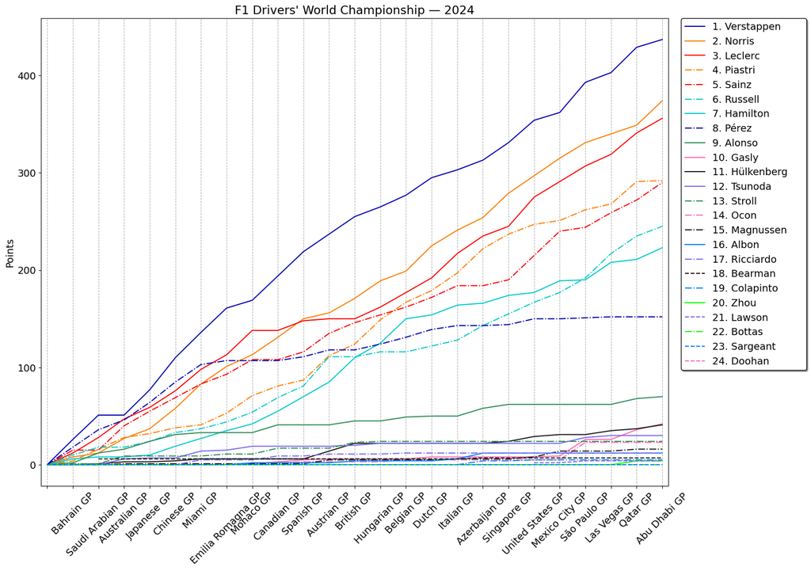

Tuy nhiên, Sergio Pérez (Red Bull) lại có một mùa giải khá chật vật khi chỉ giành được 152 điểm và 4 lần lên bục podium, xếp thứ 8 chung cuộc. Khoảng cách điểm số quá lớn giữa Verstappen và Pérez cho thấy Red Bull vẫn phụ thuộc rất nhiều vào phong độ cá nhân của Verstappen.

2. McLaren: Sự Trỗi Dậy Ngoạn Mục McLaren đã có một mùa giải 2024 thực sự bùng nổ. Lando Norris với 374 điểm, 4 chiến thắng và 13 lần lên bục podium đã vươn lên vị trí thứ 2 chung cuộc, thể hiện sự tiến bộ vượt bậc và trở thành đối trọng chính của Verstappen.

Oscar Piastri, đồng đội của Norris, cũng có một mùa giải xuất sắc với 292 điểm, 2 chiến thắng và 8 lần lên bục podium, xếp thứ 4. Sự kết hợp mạnh mẽ của hai tay đua này đã giúp McLaren trở thành một đối thủ cực kỳ đáng gờm, khẳng định tiềm lực của đội trong tương lai.

3. Ferrari: Phong Độ Ổn Định, Thiếu Đột Phá Charles Leclerc (356 điểm, 3 chiến thắng, 13 podium) và Carlos Sainz (290 điểm, 2 chiến thắng, 9 podium) của Ferrari duy trì phong độ khá ổn định, lần lượt xếp thứ 3 và thứ 5. Dù có nhiều podium và chiến thắng, Ferrari dường như vẫn còn thiếu một chút gì đó để thực sự thách thức Red Bull và McLaren một cách nhất quán trong cả mùa giải.
4. Mercedes: Mùa Giải Khó Khăn George Russell (245 điểm) và Lewis Hamilton (223 điểm) của Mercedes xếp thứ 6 và thứ 7, không có chiến thắng nào. Đây là một mùa giải khó khăn đối với Mercedes, cho thấy họ vẫn đang tìm cách khắc phục những vấn đề về hiệu suất và theo kịp các đội dẫn đầu. Sự kiện Hamilton ra đi vào cuối mùa giải càng làm tăng thêm sự chú ý về hướng đi của đội.
5. Các Đội Khác: Những Khoảnh Khắc Lóe Sáng Aston Martin với Fernando Alonso (70 điểm) vẫn duy trì được vị trí trong top 10, nhưng Lance Stroll (24 điểm) lại kém xa.

Các đội như Alpine, Haas, RB F1 Team, Williams, và Sauber chủ yếu cạnh tranh ở nửa cuối bảng xếp hạng. Tuy nhiên, cũng có những điểm sáng đáng chú ý từ các tay đua như Nico Hülkenberg (Haas) và Yuki Tsunoda (RB F1 Team) với số điểm đáng kể.

Đặc biệt, Oliver Bearman (Haas) và Franco Colapinto (Williams) dù chỉ tham gia một vài chặng nhưng vẫn kịp ghi điểm, cho thấy tiềm năng của những tài năng trẻ này.

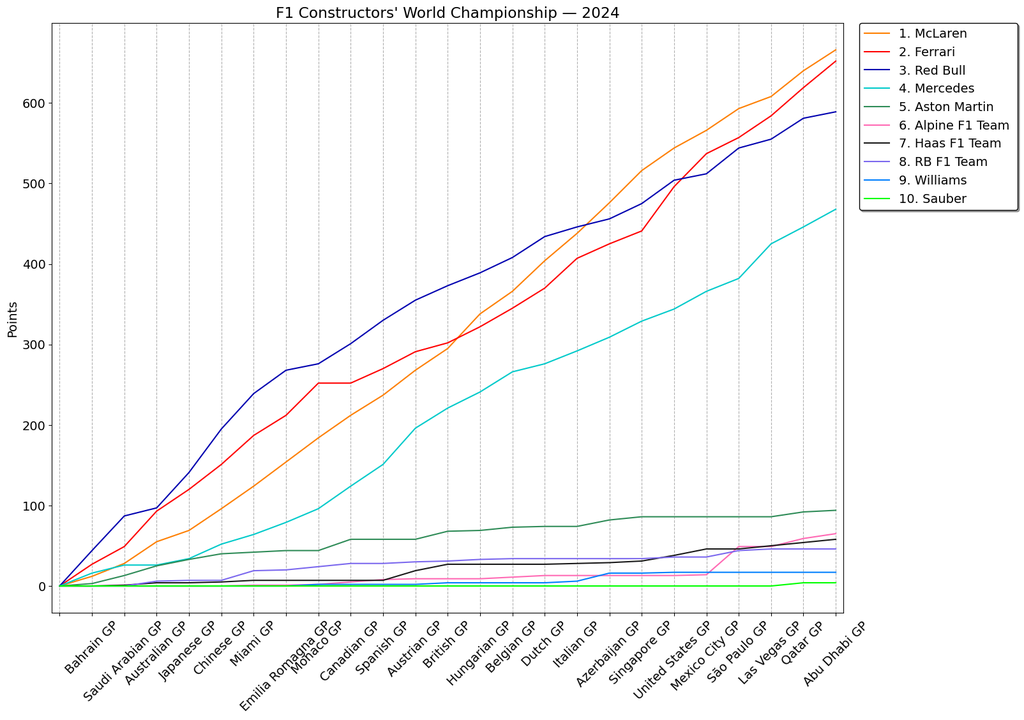

Dữ liệu về Giải Vô Địch Nhà Sản Xuất F1 2024 cho thấy một sự thay đổi đáng kể trong cục diện cạnh tranh so với những mùa giải gần đây. McLaren đã có một mùa giải bùng nổ và vượt lên dẫn trước, trong khi Red Bull dù vẫn mạnh nhưng không thể giữ vững vị thế thống trị tuyệt đối.

Tuy nhiên, một số đội đã có những màn trình diễn đáng khen ngợi trong khả năng của mình. Ví dụ, Haas với 58 điểm đã cho thấy sự cải thiện đáng kể. Sự xuất hiện của các tay đua dự bị như Oliver Bearman (Haas), Jack Doohan (Alpine), Liam Lawson (RB) và Franco Colapinto (Williams) cũng góp phần nhỏ vào tổng điểm của đội, đồng thời mang đến những cơ hội đáng giá cho thế hệ tương lai.

Tóm lại, Giải Vô Địch Nhà Sản Xuất F1 2024 đã chứng kiến McLaren vươn lên mạnh mẽ để giành ngôi vương, phá vỡ chuỗi chiến thắng của Red Bull và Mercedes. Điều này hứa hẹn một tương lai đầy cạnh tranh và hấp dẫn hơn cho F1 với sự xuất hiện của các thế lực mới.

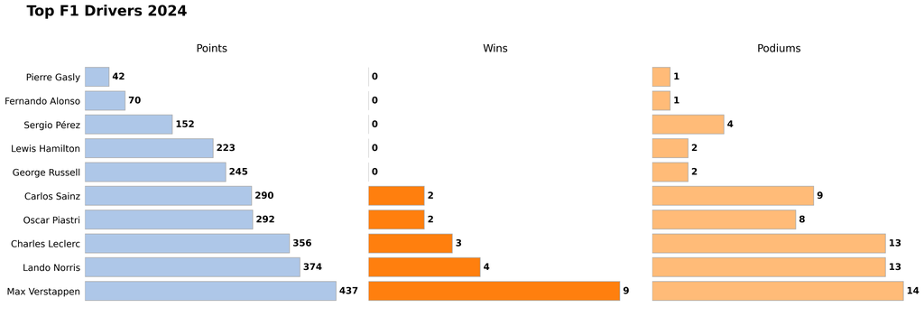

Biểu đồ trình bày trực quan điểm số, số trận thắng (Wins) và số lần lên bục Podium của 10 tay đua hàng đầu mùa giải F1 2024. Phân tích này sẽ tập trung vào cột "Points" để đánh giá sự chênh lệch.

1. Khoảng cách giữa Hạng 1 và Hạng 2: Max Verstappen và Lando Norris Max Verstappen (Hạng 1): 437 điểm

Lando Norris (Hạng 2): 374 điểm

Khoảng cách: 437−374=63 điểm

Nhận xét: Khoảng cách 63 điểm giữa Max Verstappen và Lando Norris cho thấy Verstappen vẫn là người dẫn đầu mạnh mẽ. Tuy nhiên, 63 điểm không phải là một khoảng cách quá lớn nếu so với những mùa giải anh hoàn toàn thống trị. Nó chỉ ra rằng Lando Norris đã tạo ra một áp lực đáng kể và là đối thủ cạnh tranh gần nhất của Verstappen, khiến cuộc đua giành chức vô địch Tay đua trở nên hấp dẫn hơn nhiều so với những mùa giải trước.

2. Sự Chênh Lệch Ở Top 3 và Top 5 Hạng 2 (Lando Norris): 374 điểm

Hạng 3 (Charles Leclerc): 356 điểm

Khoảng cách: 374−356=18 điểm

Nhận xét: Khoảng cách chỉ 18 điểm giữa Norris và Leclerc là cực kỳ sít sao. Điều này chứng tỏ cuộc đua giành vị trí Á quân (hay vị trí thứ 2 và 3) diễn ra vô cùng gay cấn giữa McLaren và Ferrari. Sự cạnh tranh này đã kéo dài đến những chặng cuối của mùa giải.

Hạng 4 (Oscar Piastri): 292 điểm

Hạng 5 (Carlos Sainz): 290 điểm

Khoảng cách: 292−290=2 điểm

Nhận xét: Khoảng cách chỉ 2 điểm giữa Piastri và Sainz là một minh chứng rõ ràng cho sự cạnh tranh khốc liệt đến từng điểm số trong nhóm top 5. Điều này cho thấy Piastri đã có một mùa giải đột phá mạnh mẽ, sánh ngang với các tay đua kinh nghiệm hơn như Sainz.

3. Khoảng Cách Giữa Nhóm Dẫn Đầu và Phần Còn Lại Sau top 5, khoảng cách điểm số bắt đầu mở rộng rõ rệt, cho thấy sự phân cấp rõ ràng trong mùa giải:

Hạng 5 (Carlos Sainz): 290 điểm

Hạng 6 (George Russell): 245 điểm

Khoảng cách: 290−245=45 điểm

Nhận xét: Khoảng cách 45 điểm này nhấn mạnh rằng Mercedes (Russell và Hamilton) đã tụt lại một khoảng đáng kể so với ba đội dẫn đầu (Red Bull, McLaren, Ferrari). Mặc dù vẫn nằm trong top 7, họ không còn ở vị thế cạnh tranh chức vô địch một cách thường xuyên.

Hạng 7 (Lewis Hamilton): 223 điểm

Hạng 8 (Sergio Pérez): 152 điểm

Khoảng cách: 223−152=71 điểm

Nhận xét: Khoảng cách 71 điểm giữa Hamilton và Pérez là rất lớn, đặc biệt khi Pérez lái chiếc xe của đội vô địch. Điều này làm nổi bật sự thiếu ổn định và phong độ không tương xứng của Sergio Pérez trong mùa giải này so với đồng đội Verstappen, và thậm chí còn kém hơn cả các tay đua Mercedes đang gặp khó khăn.

Hạng 8 (Sergio Pérez): 152 điểm

Hạng 9 (Fernando Alonso): 70 điểm

Khoảng cách: 152−70=82 điểm

Nhận xét: Khoảng cách 82 điểm này thể hiện một ranh giới rõ ràng giữa nhóm các đội hàng đầu (top 8) và các đội ở giữa bảng xếp hạng. Fernando Alonso (Aston Martin) và Pierre Gasly (Alpine) dẫn đầu nhóm này, nhưng điểm số của họ thấp hơn đáng kể so với nhóm dẫn đầu.

Kết Luận Chung Biểu đồ trực quan hóa rất rõ ràng rằng:

Max Verstappen vẫn thống trị, nhưng không còn một mình một ngựa.

Lando Norris đã trở thành đối thủ chính, tạo nên một cuộc đua hấp dẫn ở vị trí dẫn đầu.

Nhóm top 5 cạnh tranh cực kỳ khốc liệt, đặc biệt là giữa McLaren và Ferrari, cho thấy sự đồng đều về hiệu suất.

Có một khoảng cách đáng kể giữa top 5 và các vị trí còn lại, phản ánh sự phân hóa giữa các đội hàng đầu và các đội giữa bảng. Đặc biệt, sự tụt lùi của Pérez so với các tay đua top đầu là rất rõ ràng.

Nhìn chung, mùa giải F1 2024, dù vẫn có một nhà vô địch vượt trội, nhưng đã mang đến sự kịch tính và cạnh tranh cao hơn ở các vị trí dẫn đầu, đặc biệt là ở nhóm top 5.